# ss3diags2 user guide

Diagnostics, stock status and fleet impacts for Stock Synthesis, with FLR inputs and outputs

Henning Winker, Massimiliano Cardinale, Laurence T. Kell, Iago Mosqueira

24 November 2026

# 1 ss3diags2: Stock Synthesis diagnostics in FLR and ggplot2

ss3diags2 is the successor of ss3diags (Winker et al.; Carvalho et al. 2021). It reads the output of Stock Synthesis (SS3; Methot and Wetzel 2013) as returned by `r4ss::SS_output()` and provides:

- **Observations as FLR objects.** Catch, discards and length and age compositions as `FLQuants` by fleet, indices as `FLIndices`, life-history parameters as `FLPar`, all with the SS3 structure in the FLQuant dimensions (sex as `unit`, `season`, `area`). The same objects are the inputs of JABBA3 and FLicc.
- **Residual diagnostics.** One-step-ahead (OSA) residuals for compositions (Trijoulet et al. 2023), runs tests, joint residual plots, retrospective analysis (Mohn’s rho) and hindcast cross-validation (MASE), as in the diagnostics cookbook (Carvalho et al. 2021).
- **Stock status with uncertainty.** `FLStockR` objects with reference points, maximum likelihood estimates or draws from a multivariate lognormal (MVLN) approximation of the SS3 Hessian (Kell et al. 2023; Walter and Winker 2020), trajectories, Kobe plots and the production function.
- **Fishing mortality and impacts.** F-at-age by fleet, partial F by fleet, gear or area, F and stock by area, and the partial impact of fleets on the spawning stock (Wang et al. 2009), from the SS3 report without re-running SS3.
- **data.table and ggplot2.** Long tables with FLQuant dimension columns (`len`/`age`, `year`, `unit`, `season`, `area`, `iter`, `data`) that convert directly to FLR; no dplyr.

How ss3diags functions map to ss3diags2:

| ss3diags | ss3diags2 |
| --- | --- |
| `SSplotRunstest()`, `SSrunstest()` | `ss3_runs()`, `ss3plot_runs()` (indices, mean length, mean age) |
| `SSplotJABBAres()`, `SSrmse()` | `ss3plot_jres()` |
| `SSplotRetro()`, `SShcbias()` | `ss3_retro()`, `ss3_mohn()`, `ss3plot_retro()` |
| `SSplotHCxval()`, `SSmase()` | `ss3_hindcast()`, `ss3plot_hcxval()` |
| `SSdeltaMVLN()`, `SSplotKobe()` | `ss3mvln()`, `ss3stk()`, `ss3plot_trj()`, `ss3plot_kobe()`, `ss3plot()` |
| `SSsettingsBratioF()` | reference point basis in `ss3stk()` (same logic, benchmark labels) |
| `SScompsTA1.8()`, `r4ss::SSMethod.TA1.8()` | `ss3_francis()`, `ss3plot_francis()` (len, age, con, size) |
| `SSplotEnsemble()` | `ss3_ensemble()`, `ss3plot_ensemble()` |
| `SSplot_eqcurves()` | `ss3_eqcurve()`, `ss3_spm()`, `ss3plot_production()` |
| `SSgetComps()` | `ss3_lencomp()`, `ss3_agecomp()` |
| (Pearson residuals in r4ss) | `ss3_resid()` (OSA), `ss3plot_resid()` |

## 1.1 About this guide

**Part I** (sections 3-10, with a worked example for a two-sex assessment with conditional age-at-length data) goes through the diagnostics of an assessment, from the data to the prediction skill, with **checks** at each step (what to look at, what is a red flag, what to do about it), following the diagnostics cookbook. **Part II** (sections 11-16) covers stock status and its uncertainty, the timing of F and SSB in Kobe plots, the production function, season-, sex- and area-structured models (F by area, stock by area, partial impact of fleets) and the FLR outputs. Section 17 summarises the checks and the functions.

The examples ship with the package:

| Data | Model | Used for |
| --- | --- | --- |
| `ss3simple` | simulated two-sex model, one fishery and two surveys (r4ss “simple_small”; the example of the PIFSC ss3diags) | quick start, data, residuals |
| `ss3sma`, `retro.sma`, `aspm.sma` | North Atlantic shortfin mako (cookbook) | runs tests, retrospective, status, Kobe |
| `ss3phk`, `retro.phk`, `aspm.phk` | Pacific hake (cookbook) | Dirichlet-multinomial OSA residuals, hindcast |
| `hke.37.17-18.rds` | European hake in the Adriatic Sea (GFCM benchmark 2024), two sexes, eight fleets, three surveys, conditional age-at-length | worked example: growth by sex, sex ratios, conditional age-at-length, impact by gear |
| `her.27.25-2932.rds` | Central Baltic herring, three SS3 runs with alternative M | model ensembles |
| `hke.37.17-18_fwd.rds` | Adriatic hake, SS3 forecast runs for three F scenarios (`SSsummarize()` summary) | short-term forecasts |
| `pra.27.3a4a.rds` | northern shrimp, four seasons, hermaphrodite, two areas, six area-specific fleets | structured models, F by area, impact |

# 2 Installation

## 2.1 Required

ss3diags2 needs `FLCore`, `data.table` and `ggplot2`. Install from r-universe (the same repositories provide the FLR packages):

```r
repos <- c(
  hw   = "https://henning-winker.r-universe.dev",
  flr  = "https://flr.r-universe.dev",
  CRAN = "https://cloud.r-project.org"
)
install.packages("ss3diags2", repos = repos)
```

Or the development version from GitHub:

```r
remotes::install_github("Henning-Winker/ss3diags2")
```

## 2.2 Optional

| Package | Needed for | Install |
| --- | --- | --- |
| `r4ss` | reading SS3 output (`SS_output()`, `SSgetoutput()`, `SSsummarize()`) | `install.packages("r4ss")` |
| `mvtnorm`, `MASS` | MVLN draws (`ss3mvln()`, `output = "iters"`) and Kobe contours | `install.packages(c("mvtnorm", "MASS"))` |
| `patchwork` | the summary page `ss3plot()` and side-by-side plots | `install.packages("patchwork")` |
| `ss3diags` | comparing with the original functions | `remotes::install_github("jabbamodel/ss3diags")` |
| `JABBA3`, `FLicc`, `FLRef` | the models fed by the extracted inputs | see the packages |

## 2.3 Check the installation

```r
library(ss3diags2)
library(ggplot2)
packageVersion("ss3diags2")
```

```
#> [1] '0.1.0.9000'
```

```r
opt <- c("r4ss", "mvtnorm", "MASS", "patchwork", "ss3diags")
data.frame(package = opt, installed = vapply(opt, requireNamespace, logical(1), quietly = TRUE), row.names = NULL)
```

```
#>     package installed
#> 1      r4ss      TRUE
#> 2   mvtnorm      TRUE
#> 3      MASS      TRUE
#> 4 patchwork      TRUE
#> 5  ss3diags      TRUE
```

# 3 Quick start

An SS3 run is read with `r4ss::SS_output()`; the report list is the input of ss3diags2. The simulated `ss3simple` model ships with the package (its SS3 files are in `system.file("extdata", "simple_small", package = "r4ss")`):

```r
ss3rep <- r4ss::SS_output("path/to/run", verbose = FALSE, printstats = FALSE)
```

```r
data(ss3simple)
ss3_fleets(ss3simple)
```

```
#>    fleet    name   type  area catch_units survey_units ncatch nindex  nlen  nage
#>    <int>  <char> <char> <int>      <char>       <char>  <int>  <int> <int> <int>
#> 1:     1 FISHERY  catch     1     biomass      biomass     13      0    12    12
#> 2:     2 SURVEY1 survey     1        <NA>      biomass      0      4     4     4
#> 3:     3 SURVEY2 survey     1        <NA>      numbers      0     12     0     0
```

## 3.1 Quick output: `ss3plot()`

`ss3plot()` is the one-page summary of an assessment, as the JABBA3 summary plot:

- **top row:** SSB (with the observed indices scaled to SSB as points), F and catch, with the reference points (unfished in blue, targets in green, Bpa orange, Blim red);
- **middle row:** SSB and F relative to their targets, and the Kobe plot with the uncertainty of the terminal year;
- **bottom row:** the stock-recruitment curve, the recruitment deviations with 95% intervals and the production phase plot (catch against SSB on the Kobe colours, with the equilibrium yield curve).

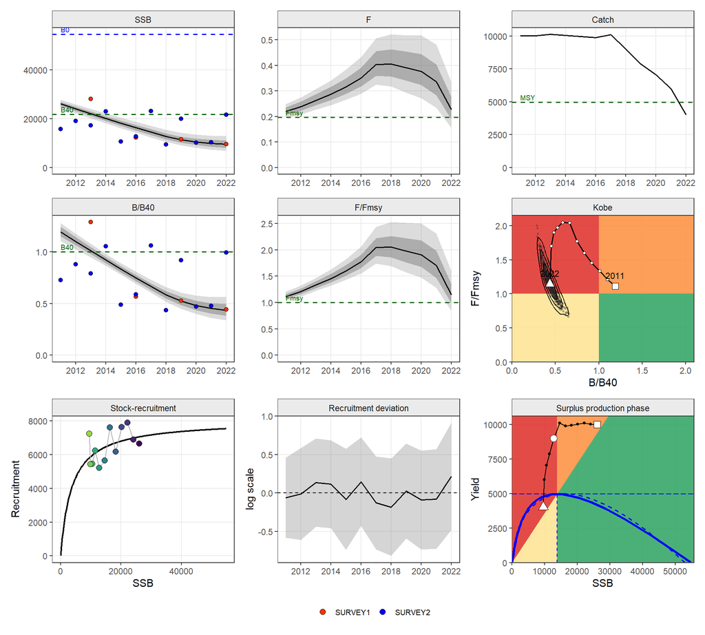

```r
ss3plot(ss3simple, iters = 500)
```

Uncertainty comes from MVLN draws of the SS3 Hessian. The targets are named after the benchmark SS3 used (here `B40`: 40% of unfished SSB, with `Fmsy`; section [Stock status]).

## 3.2 Stock status as FLR

```r
stk <- ss3stk(ss3simple)                     # FLStockR at the MLE, reference points in @refpts
stk@refpts
```

```
#> An object of class "FLPar"
#> params
#>     Ftgt     Btgt      MSY       B0       R0
#> 1.98e-01 2.19e+04 4.96e+03 5.48e+04 7.54e+03
#> units:  NA
```

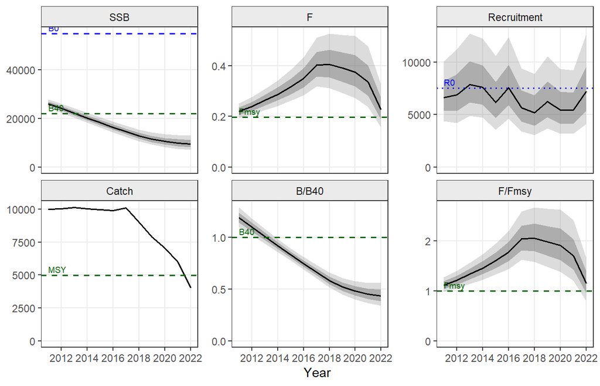

```r
ss3plot_trj(stk)
```

# 4 Data: observations as FLR objects

The extraction functions return the observations of an SS3 run, and with `what = "exp"` the model fit, as FLR objects. Each fleet is one element of an `FLQuants`; the SS3 structure goes into the FLQuant dimensions:

| SS3 | FLQuant dimension | note |
| --- | --- | --- |
| length or age bin | `len` / `age` | data bins; empty bins of sampled compositions are filled with 0 |
| year | `year` |  |
| sex (data `Sexes` 1-3) | `unit` | `F`, `M`; combined-sex data stay `unique` |
| season | `season` | seasons stay seasons |
| area | `area` | the area of the fleet |
| partition 0/1/2 | fleet name | `fleet.all`, `fleet.discard`, `fleet.retained` |

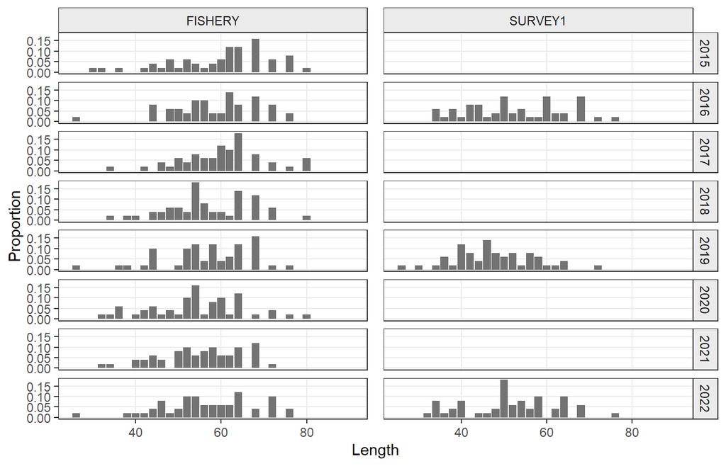

```r
ct  <- ss3_catch(ss3simple)                  # FLQuants: catch by fleet
idx <- ss3_indices(ss3simple)                # FLIndices of FLIndexBiomass: index, index.var (input SE)
lfd <- ss3_lencomp(ss3simple)                # FLQuants: length compositions by fleet, sex as unit
afd <- ss3_agecomp(ss3simple)

ss3plot_comps(lfd,type="annual",year=2015:2022)
```

Every extractor also returns the long `data.table` (`long = TRUE`), with the FLQuant dimension columns:

```r
head(ss3_lencomp(ss3simple, long = TRUE), 3)
```

```
#>    fleet    name partname   len  year   unit season   area   iter        data
#>    <int>  <char>   <char> <int> <int> <char> <char> <char> <char>       <num>
#> 1:     1 FISHERY  FISHERY    26  2011      F    all unique      1 0.004975125
#> 2:     1 FISHERY  FISHERY    28  2011      F    all unique      1 0.004975125
#> 3:     1 FISHERY  FISHERY    30  2011      F    all unique      1 0.004975125
#>     part ageerr month         obs        exp   pearson nsamp_adj nsamp_in    effN
#>    <int>  <int> <int>       <num>      <num>     <num>     <int>    <int>   <num>
#> 1:     0      0     7 9.95025e-05 0.00167172 -0.272132        50       50 43.6548
#> 2:     0      0     7 9.95025e-05 0.00113472 -0.217430        50       50 43.6548
#> 3:     0      0     7 9.95025e-05 0.00146581 -0.252530        50       50 43.6548
#>      used nsamp           n      nexp   units
#>    <char> <int>       <num>     <num>  <char>
#> 1:    yes    50 0.004975125 0.0835860 numbers
#> 2:    yes    50 0.004975125 0.0567360 numbers
#> 3:    yes    50 0.004975125 0.0732905 numbers
```

## 4.1 Data overview

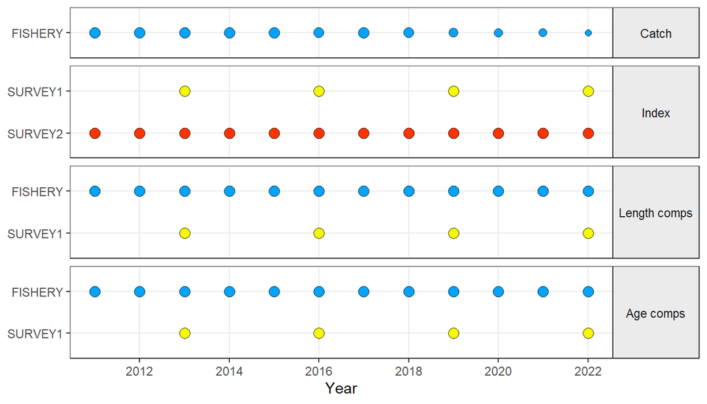

```r
ss3plot_data(catch = ct, indices = idx, lencomp = lfd, agecomp = afd)
```

## 4.2 Compositions

`ss3plot_comps()` shows compositions pooled over years, by year, as bubbles (only the years with data) or as mean length or age over time, split by `unit`, `season` or `area` (`by =`), for a subset of `fleets` and `units`:

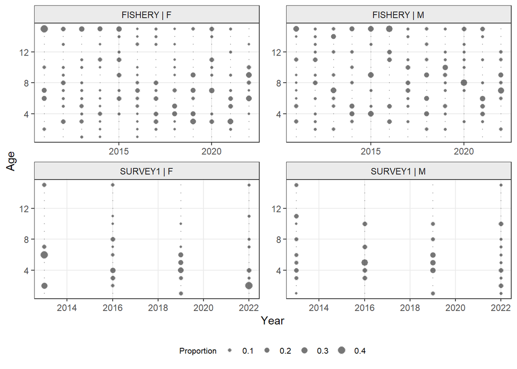

```r
ss3plot_comps(afd, type = "bubble", by = "unit")
```

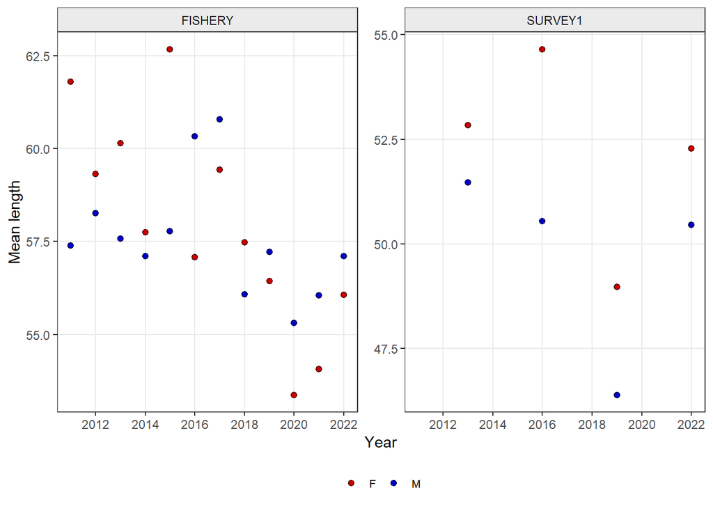

```r
ss3plot_comps(lfd, type = "mean", by = "unit")
```

## 4.3 Inputs for JABBA3 and FLicc

`ss2jabba3()` returns catch in weight by fleet and annual indices with input SEs, the inputs of JABBA3; `ss2flicc()` returns length compositions by gear on common bins, with `ss3_lhpar()`, the inputs of FLicc.

```r
j <- ss2jabba3(ss3simple)
names(j)
```

```
#> [1] "catch"       "indices"     "fleets"      "catch.total"
```

> **Check 1: data.** Look for contrast in the indices (a one-way trip gives little information on productivity), conflicting trends between indices, and compositions with few samples or gaps. `ss3plot_nsamp()` shows the input and effective sample sizes.

# 5 Life history and growth

`ss3_lhpar()` returns an `FLPar` of growth, maturity, length-weight and natural mortality, with a `unit` dimension when the model has two sexes; this is the `lhpar` of FLicc. Growth other than von Bertalanffy is approximated by a von Bertalanffy curve fitted to the SS3 growth at the end year.

```r
lh <- ss3_lhpar(ss3simple)
lh
```

```
#> An object of class "FLPar"
#>            unit
#> params      F         M
#>   linf       7.33e+01  7.33e+01
#>   k          1.42e-01  1.42e-01
#>   t0        -2.62e+00 -2.62e+00
#>   L50        5.50e+01  5.50e+01
#>   mat.slope -2.50e-01 -2.50e-01
#>   a          2.44e-06  2.44e-06
#>   b          3.35e+00  3.35e+00
#>   M          1.00e-01  1.00e-01
#>   CVmin      1.00e-01  1.00e-01
#>   CVmax      1.00e-01  1.00e-01
#>   A1         0.00e+00  0.00e+00
#>   A2         2.00e+01  2.00e+01
#>   L1         2.28e+01  2.28e+01
#>   L2         7.03e+01  7.03e+01
#>   K          1.42e-01  1.42e-01
#>   richards   1.00e+00  1.00e+00
#>   settle     0.00e+00  0.00e+00
#>   cvtype     0.00e+00  0.00e+00
#>   amax       2.00e+01  2.00e+01
#>   sdadd      0.00e+00  0.00e+00
#> units:  NA NA NA NA NA NA NA NA NA NA NA NA NA NA NA NA NA NA NA NA
```

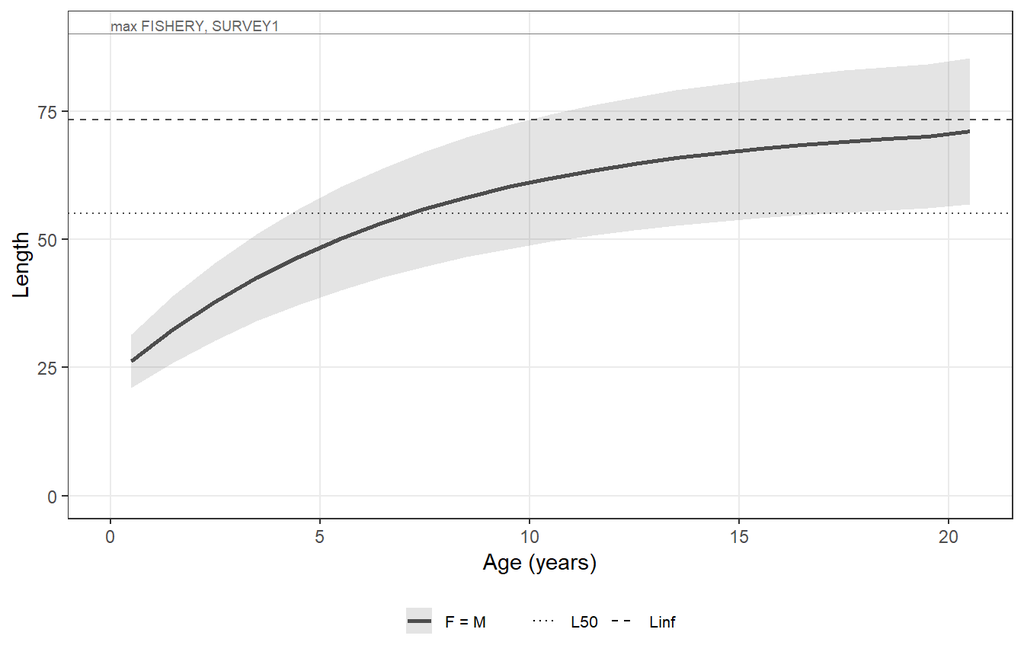

```r
ss3plot_growth(ss3simple, lfd = lfd)
```

Ridge plots show the length compositions by year, observed (filled) and expected (lines), with the growth curves by sex tracking cohorts through the bins:

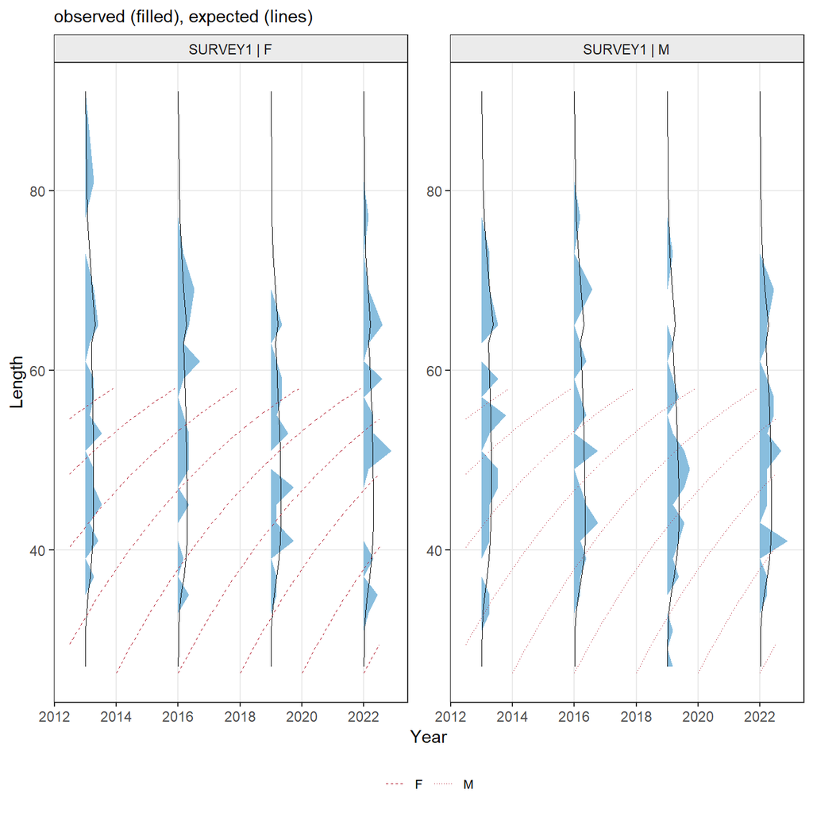

```r
ss3plot_ridges(lfd, fit = ss3_lencomp(ss3simple, what = "exp"), type = "both", fleets = "SURVEY1", lhpar = lh)
```

# 6 Check 2: model fits

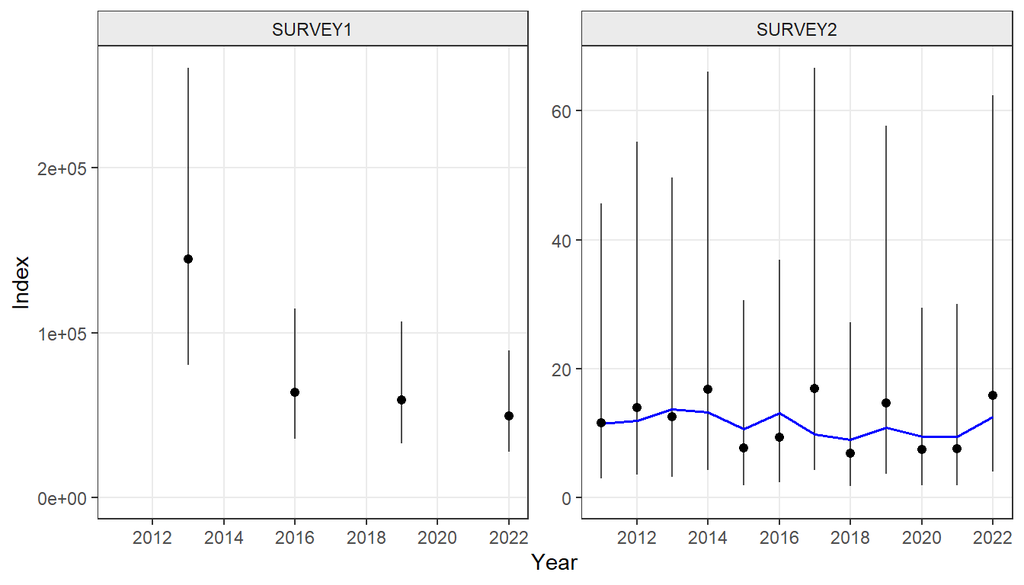

```r
ss3plot_indices(idx, fit = ss3_indices(ss3simple, what = "exp"))
```

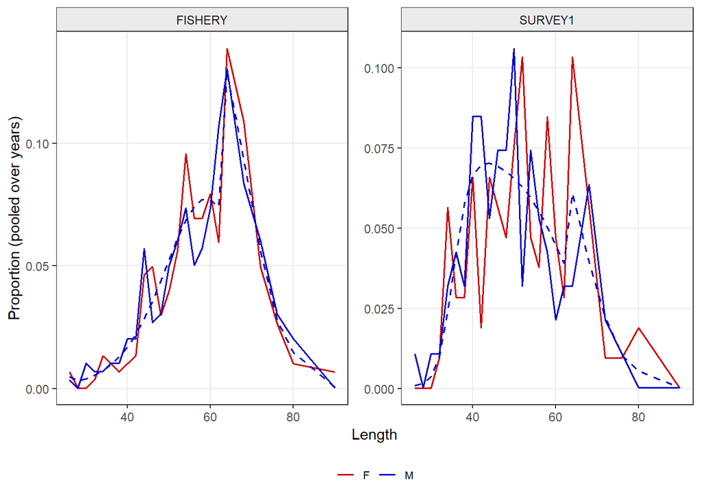

```r
ss3plot_comps(lfd, fit = ss3_lencomp(ss3simple, what = "exp"), by = "unit")
```

> **Check 2: fits.** The fitted index should follow the trend of each index; systematic misfits at the start or end of a series, or an index fitted only where it agrees with another, point to conflicts between data sources. Pooled compositions should be fitted without systematic misfit of the small or large bins.

# 7 Check 3: residual diagnostics

## 7.1 One-step-ahead residuals for compositions

Pearson residuals of multinomial compositions are correlated across bins (they must add up), so their patterns can mislead. **One-step-ahead (OSA) residuals** (Trijoulet et al. 2023) condition each bin on the bins before it; under a correct model they are independent N(0, 1). `ss3_resid()` computes them for the SS3 likelihood: multinomial with the adjusted sample size, or Dirichlet-multinomial with the precision implied by the SS3 effective sample size. Growth curves by sex (`lhpar`) track cohorts.

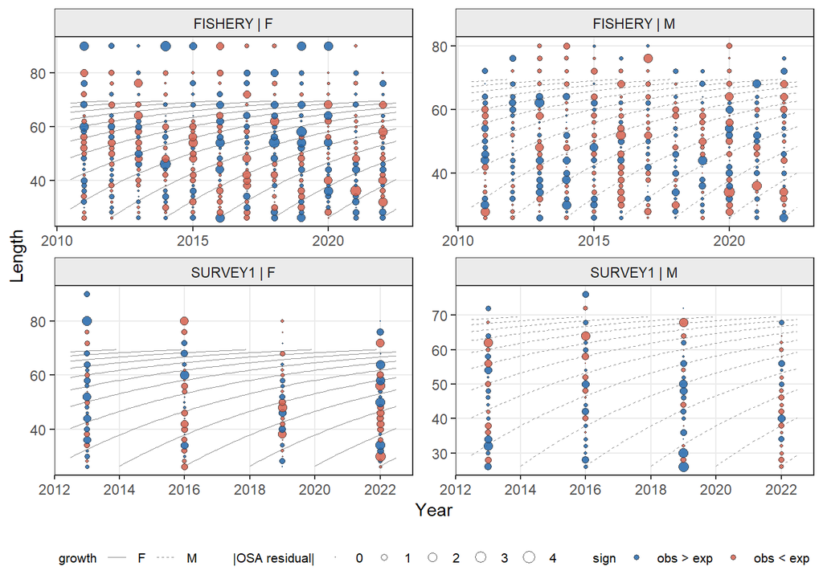

```r
rl <- ss3_resid(ss3simple)                   # length; ss3_resid(ss3simple, "age") for ages
ss3plot_resid(rl, lhpar = lh)
```

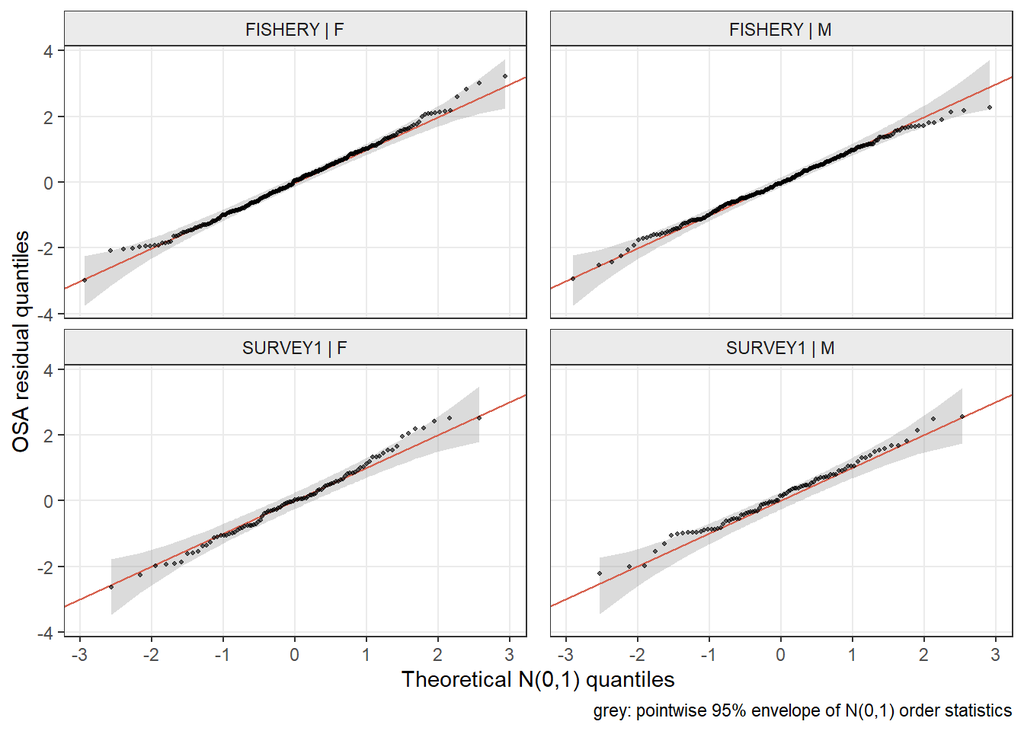

```r
ss3plot_resid(rl, type = "qq")
```

### 7.1.1 Testing the OSA residuals

`ss3_osatest()` tests, for each composition (fleet and sex, as the panels of the plots), whether the OSA residuals follow their theoretical N(0, 1) distribution:

- the Anderson-Darling statistic against a fixed N(0, 1), with a Monte Carlo p-value: PASS when p >= 0.05;
- descriptive checks: the mean (near 0), the SD (near 1), the RMSE of the QQ plot from the 1:1 line, and the share of residuals outside +-1.96 (about 5% expected).

```r
ss3_osatest(rl, nsim = 499)
```

```
#>          panel     N   mean    SD QQ RMSE    AD     p result outside 1.96 (%)
#>         <fctr> <int>  <num> <num>   <num> <num> <num> <char>            <num>
#> 1: FISHERY | F   299  0.018 1.031   0.076 0.282 0.970   PASS              5.4
#> 2: FISHERY | M   276 -0.008 0.940   0.080 0.344 0.912   PASS              2.9
#> 3: SURVEY1 | F    97  0.011 1.116   0.148 0.561 0.718   PASS              9.3
#> 4: SURVEY1 | M    88  0.131 0.980   0.158 0.862 0.474   PASS              6.8
```

`test = TRUE` shades each panel of the residual plots light green (PASS) or light red (FAIL). The QQ plots have pointwise 95% envelopes of the order statistics of a standard normal sample (`envelope = TRUE`, the default):

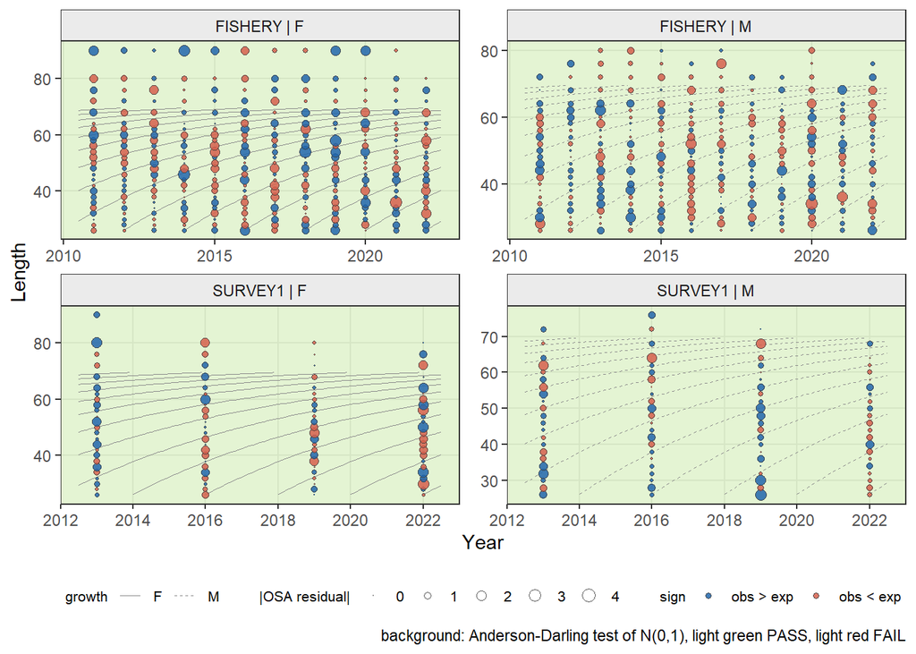

```r
ss3plot_resid(rl, lhpar = lh, test = TRUE, nsim = 199)
```

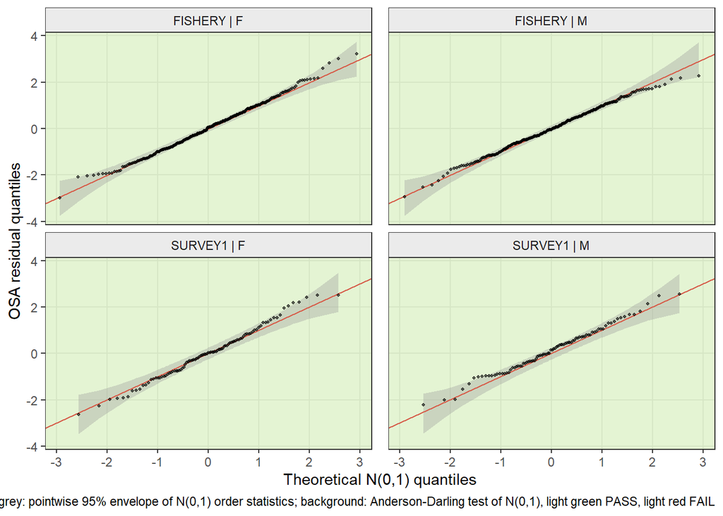

```r
ss3plot_resid(rl, type = "qq", test = TRUE, nsim = 199)
```

> **Reading the OSA tests.** A FAIL means the residuals of that composition depart significantly from N(0, 1). A shifted mean points to a bias (e.g. selectivity), an SD above 1 to too little variance in the likelihood (data weighted too much), and an SD below 1 to too much. Treat the results as flags, not as verdicts on the model. The Monte Carlo p-value and the QQ envelopes assume independent residuals, so cohort or year effects make them too strict, and testing many fleets and models raises the chance of false failures. Points outside the envelope in the tails of a QQ plot show where the departures are.

Pacific hake uses the Dirichlet-multinomial for its age compositions:

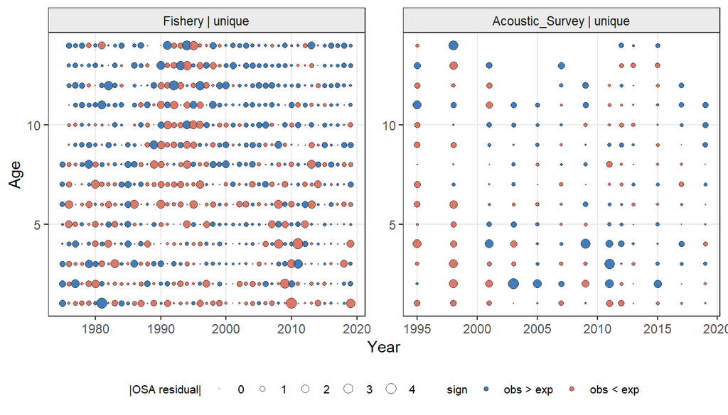

```r
data(ss3phk)
ss3plot_resid(ss3_resid(ss3phk, "age"), cohorts = FALSE)
```

## 7.2 Conditional age-at-length

Conditional age-at-length data are a multinomial over ages for each length bin, so `ss3_resid(quant = "con")` computes OSA residuals per length bin; `long = TRUE` keeps the bin for `ss3plot_caal()`. Runs tests, joint residuals, hindcasts (`quant = "con"`) and Francis weights (`ss3_francis(quant = "con")`, as `r4ss::SSMethod.Cond.TA1.8()`) work on the mean age by length bin. Section Conditional age-length key example: European hake in the Adriatic Sea goes through these diagnostics for a two-sex assessment with conditional age-at-length data.

> **Reading OSA residuals.** Bins are conditioned on the smaller bins: too few small fish gives negative residuals at small sizes and positive residuals at larger sizes. Diagonal patterns that follow the growth curves are year classes the model does not fit.

## 7.3 Data weighting: Francis TA1.8

The Francis (2011) TA1.8 weight compares the observed mean length (or age) of each composition with its expected value; with correct weighting the standardised residuals have variance 1. `ss3_francis()` gives the weight $w = 1/\mathrm{var}(\mathrm{std.res})$ by fleet with a bootstrap interval and the new SS3 variance adjustment (current adjustment times $w$), as `r4ss::SSMethod.TA1.8()`:

```r
fw <- ss3_francis(ss3simple)
fw
```

```
#>      fleet         w        lo         hi     n var_adj var_adj.new
#>     <char>     <num>     <num>      <num> <int>   <num>       <num>
#> 1: FISHERY 1.3108137 0.7265679   4.435607    12       1   1.3108137
#> 2: SURVEY1 0.5572836 0.3734109 749.390232     4       1   0.5572836
```

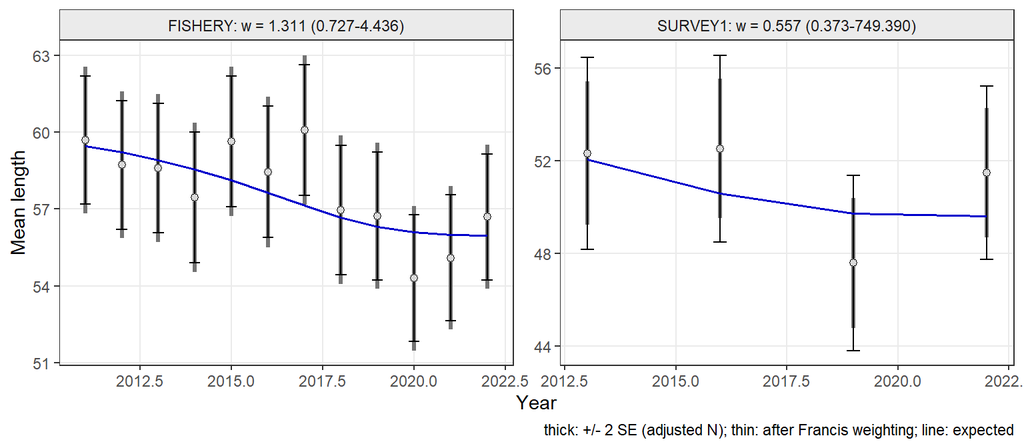

```r
ss3plot_francis(fw)
```

> **Check: data weighting.** $w < 1$: the compositions are overweighted relative to the variation of their mean lengths; multiply the variance adjustment of the fleet by $w$ and rerun. Wide intervals (few compositions) mean the weight is poorly determined. Dirichlet-multinomial fleets estimate their weight and need no tuning.

## 7.4 Runs tests and joint residuals

The runs test checks the log residuals of each index (or the mean length or age) for randomness; the 3-sigma limits come from the average moving range (Carvalho et al. 2021). North Atlantic shortfin mako:

```r
data(ss3sma)
ss3_runs(ss3sma)
```

```
#>     index runs.p   test  sigma3.lo sigma3.hi
#>    <char>  <num> <char>      <num>     <num>
#> 1: CPUE_1  0.069 Passed -0.2605783 0.2605783
#> 2: CPUE_2  0.717 Passed -0.7630777 0.7630777
#> 3: CPUE_3  0.229 Passed -0.5033328 0.5033328
#> 4: CPUE_4  0.406 Passed -0.5868380 0.5868380
#> 5: CPUE_5  0.065 Passed -0.3369695 0.3369695
#> 6: CPUE_6  0.870 Passed -3.0226356 3.0226356
```

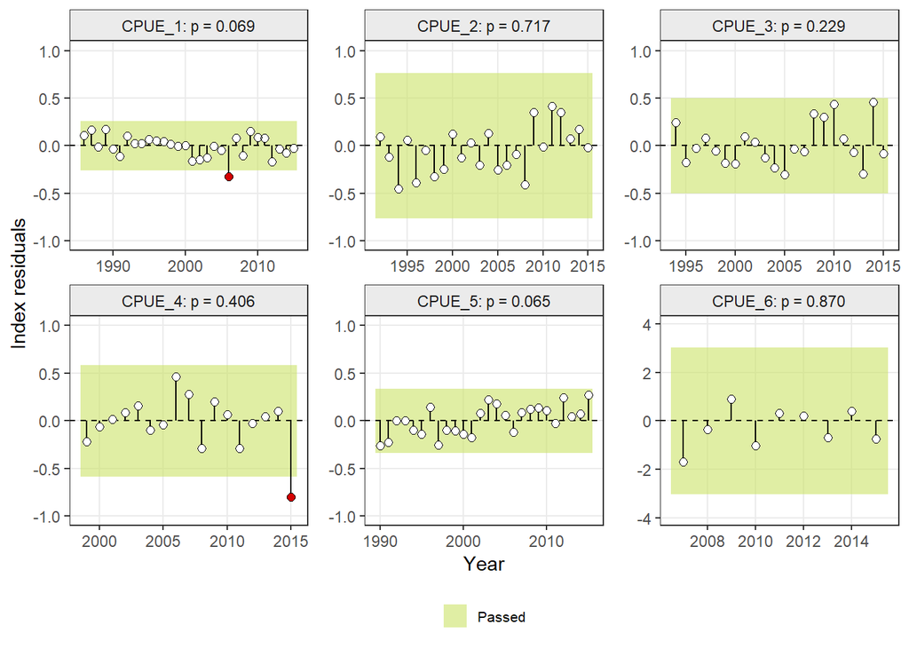

```r
ss3plot_runs(ss3sma)
```

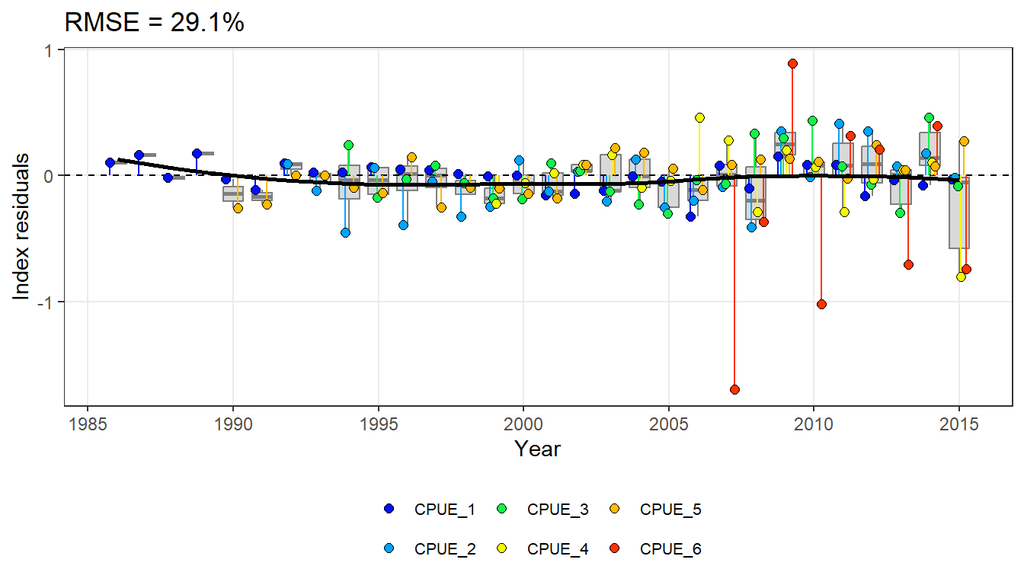

```r
ss3plot_jres(ss3sma)
```

> **Check 3: residuals.** Red flags: a failed runs test (p < 0.05), residuals outside the 3-sigma limits, trends in the joint residuals (lowess line), RMSE above 30%. Actions: look for conflicts between indices, changes in catchability, selectivity or growth; never drop data only to pass a test.

# 8 Check 4: retrospective analysis

Retrospective runs refit the model with the last years of data removed (peels; `r4ss::retro()`), read with `r4ss::SSgetoutput()` (and optionally `r4ss::SSsummarize()`). `ss3_retro()` turns them into `FLStocks` (one `FLStockR` per peel); `ss3_mohn()` gives Mohn’s rho and the forecast rho (the one-year-ahead projection of each peel against the reference run), as `ss3diags::SShcbias()`.

```r
data(retro.sma)
rt <- ss3_retro(retro.sma)
ss3_mohn(rt, c("SSB", "F"))
```

```
#>      quant     peel          rho       fcrho
#>     <char>   <char>        <num>       <num>
#>  1:    SSB     2014  0.020093362  0.02045794
#>  2:    SSB     2013  0.042894147  0.04379605
#>  3:    SSB     2012  0.063855565  0.06529724
#>  4:    SSB     2011  0.087619622  0.08975344
#>  5:    SSB     2010  0.083003822  0.08466103
#>  6:    SSB Combined  0.059493304  0.06079314
#>  7:      F     2014 -0.019624432 -0.02679539
#>  8:      F     2013 -0.002872149 -0.01684454
#>  9:      F     2012 -0.042739851 -0.06472934
#> 10:      F     2011 -0.085448219 -0.10706880
#> 11:      F     2010 -0.078531045 -0.10968634
#> 12:      F Combined -0.045843139 -0.06502488
```

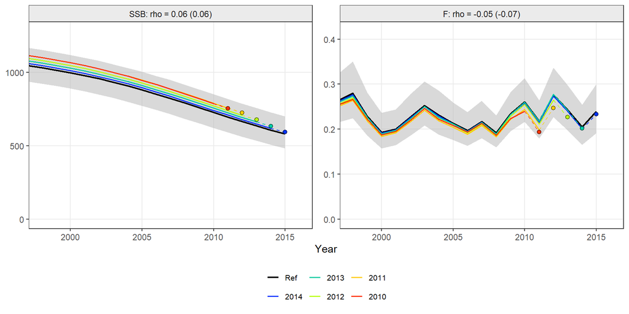

```r
ss3plot_retro(rt, type = c("SSB", "F"))
```

> **Check 4: retrospective.** Mohn’s rho outside -0.15 to 0.20 (long-lived species; -0.22 to 0.30 for short-lived species; Hurtado-Ferro et al. 2015) is a red flag, as are forecasts outside the confidence interval of the reference run. Actions: look at recent data, time-varying catchability or selectivity.

# 9 Check 5: hindcast cross-validation

The hindcast compares the observations of the peeled years with their one-year-ahead predictions from the retrospective runs (Kell et al. 2016). The mean absolute scaled error (MASE) scales the prediction error by that of a naive random-walk forecast: MASE < 1 means the model predicts better than the naive forecast. `ss3_hindcast()` does indices, mean length and mean age, as `ss3diags::SSmase()`.

```r
data(retro.phk)
hc <- ss3_hindcast(retro.phk)
hc$mase
```

```
#>              index     MASE    MAE.PR  MAE.base MASE.adj n.eval
#>             <char>    <num>     <num>     <num>    <num>  <int>
#> 1: Acoustic_Survey 1.064745 0.3022749 0.2838943 1.064745      4
#> 2:           joint 1.064745 0.3022749 0.2838943 1.064745      4
```

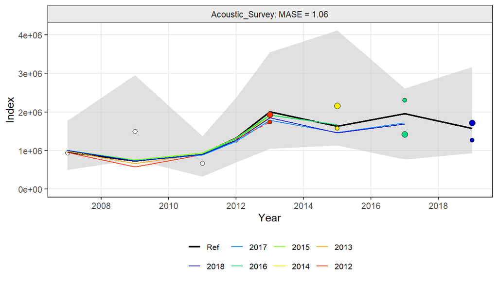

```r
ss3plot_hcxval(hc)
```

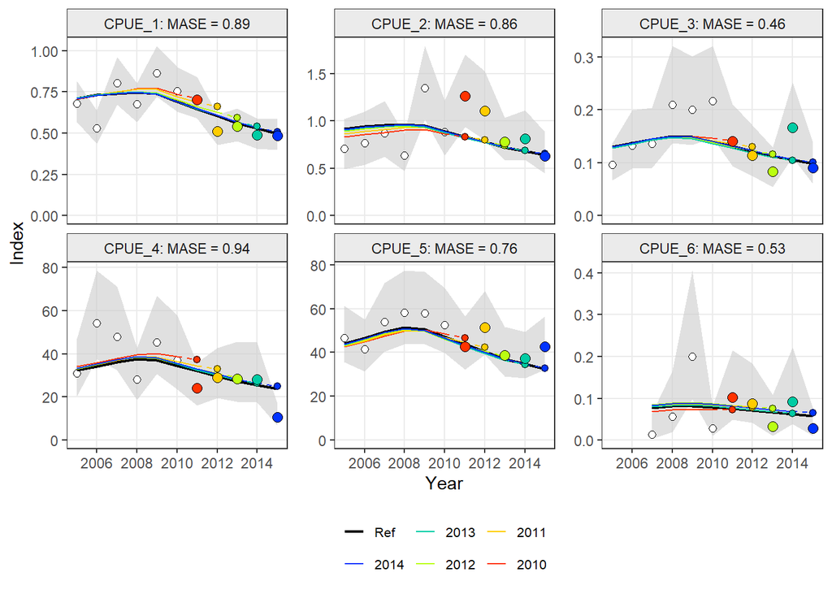

```r
ss3plot_hcxval(ss3_hindcast(retro.sma))
```

> **Check 5: prediction skill.** MASE > 1 for an index means the model has no prediction skill for it. With indices that vary little the naive error is small and `MAE.base.adj` (default 0.1) limits the scaling.

## 9.1 Hindcasts of mean length and mean age

Compositions carry information on stock dynamics too, so the hindcast can also be applied to the mean length (`quant = "len"`) or mean age (`quant = "age"`) of each fleet, as in the Stock Synthesis diagnostics cookbook (Carvalho et al. 2021). The observed and predicted compositions are reduced to their annual means (sexes and partitions pooled) and the one-year-ahead predictions of the peels are scored with MASE as for the indices. Conditional age-at-length (`"con"`) and generalised size compositions (`"size"`) work the same way. Compositions need the full reports of the retrospective runs (`r4ss::SSgetoutput()`), not their `SSsummarize()` summary.

The mako shark model has length compositions only:

```r
hc.len <- ss3_hindcast(retro.sma, quant = "len")
hc.len$mase
```

```
#>        index      MASE     MAE.PR   MAE.base  MASE.adj n.eval
#>       <char>     <num>      <num>      <num>     <num>  <int>
#> 1: Fishery_1 0.9265301 0.02981727 0.03218165 0.2981727      5
#> 2: Fishery_2 0.6504563 0.07615571 0.11708045 0.6504563      4
#> 3: Fishery_3 0.4871654 0.01440356 0.02956605 0.1440356      1
#> 4: Fishery_4 0.6359712 0.03788656 0.05957277 0.3788656      5
#> 5: Fishery_5 1.8926102 0.03716808 0.01963853 0.3716808      2
#> 6:     joint 0.7348675 0.04305187 0.05858453 0.4305187     17
```

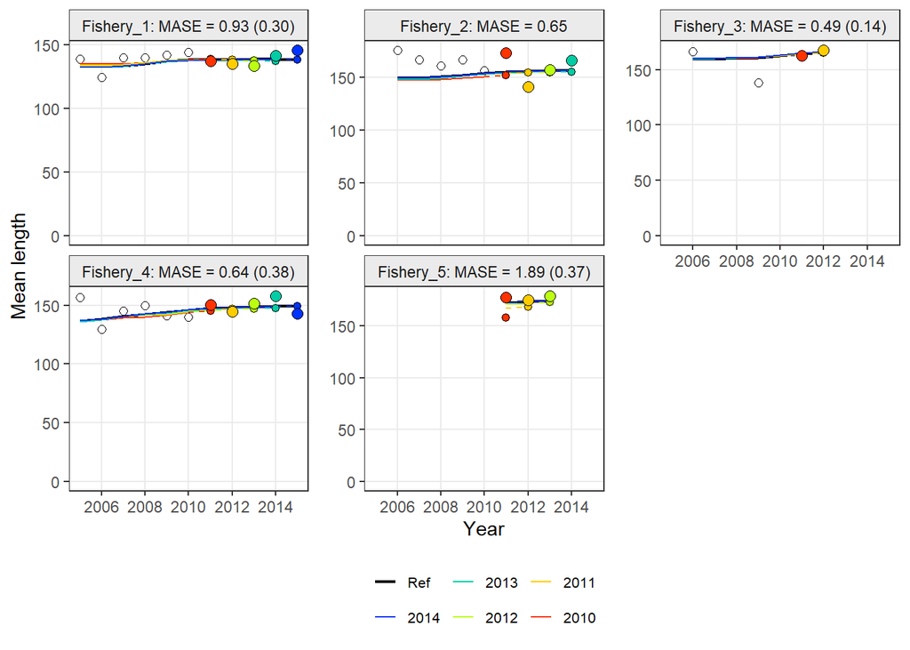

```r
ss3plot_hcxval(hc.len)
```

The Pacific hake model has age compositions of the fishery and the acoustic survey:

```r
hc.age <- ss3_hindcast(retro.phk, quant = "age")
hc.age$mase
```

```
#>              index      MASE     MAE.PR  MAE.base  MASE.adj n.eval
#>             <char>     <num>      <num>     <num>     <num>  <int>
#> 1:         Fishery 0.6319721 0.09063054 0.1434091 0.6319721      7
#> 2: Acoustic_Survey 0.3556384 0.05181084 0.1456841 0.3556384      4
#> 3:           joint 0.5304785 0.07651428 0.1442363 0.5304785     11
```

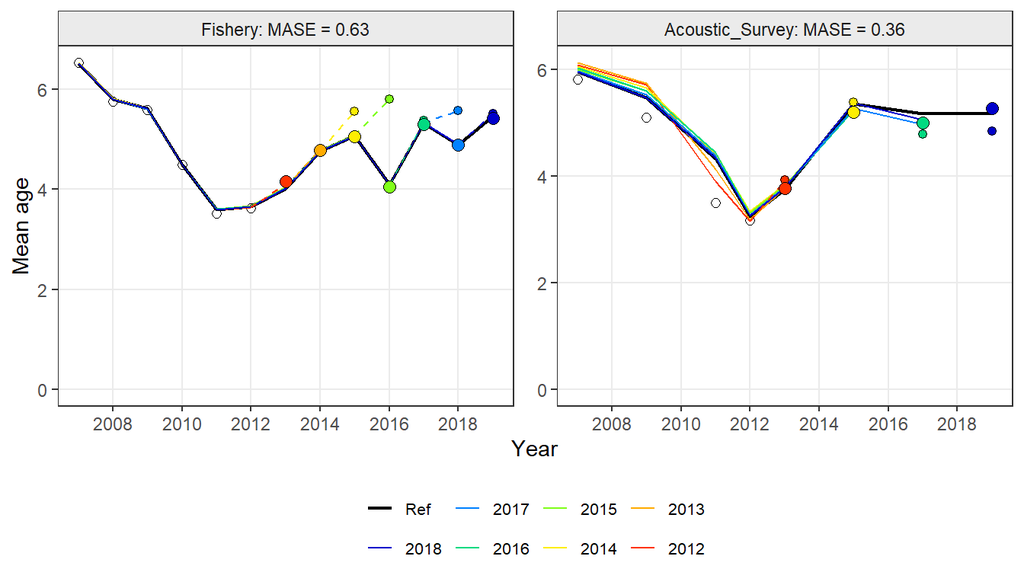

```r
ss3plot_hcxval(hc.age)
```

> **Mean length and age.** MASE < 1 means that the model predicts the mean length or age of the next year better than last year’s observed mean does. Fleets with few hindcast years (`n.eval`) give unstable MASE: read them with the joint value. Mean lengths often vary little between years, so `MASE.adj` (naive error at least `MAE.base.adj`) is the more robust measure for them.

## 9.2 All checks at a glance: the model scorecard

`ss3_scorecard()` collects the checks of this guide into one pass/fail table for one or more models:

Criteria a model cannot provide (e.g. without retrospective runs) are left grey. Here the mako shark and Pacific hake models are side by side, to show the layout:

```r
sc <- ss3_scorecard(list(mako = ss3sma, `Pacific hake` = ss3phk), retro = list(mako = retro.sma, `Pacific hake` = retro.phk),
                    nsim = 199)
sc$table
```

```
#>           model Runs index: CPUE_1 Runs index: CPUE_2 Runs index: CPUE_3
#>          <char>              <int>              <int>              <int>
#> 1:         mako                  1                  1                  1
#> 2: Pacific hake                 NA                 NA                 NA
#>    Runs index: CPUE_4 Runs index: CPUE_5 Runs index: CPUE_6
#>                 <int>              <int>              <int>
#> 1:                  1                  1                  1
#> 2:                 NA                 NA                 NA
#>    Runs index: Acoustic_Survey Retro SSB rho Forecast SSB rho MASE index: CPUE_1
#>                          <int>         <int>            <int>              <int>
#> 1:                          NA             1                1                  1
#> 2:                           1             1                1                 NA
#>    MASE index: CPUE_2 MASE index: CPUE_3 MASE index: CPUE_4 MASE index: CPUE_5
#>                 <int>              <int>              <int>              <int>
#> 1:                  1                  1                  1                  1
#> 2:                 NA                 NA                 NA                 NA
#>    MASE index: CPUE_6 MASE index: joint MASE index: Acoustic_Survey
#>                 <int>             <int>                       <int>
#> 1:                  1                 1                          NA
#> 2:                 NA                 0                           0
#>    OSA len: Fishery_1 | unique OSA len: Fishery_2 | F OSA len: Fishery_2 | M
#>                          <int>                  <int>                  <int>
#> 1:                           0                      1                      1
#> 2:                          NA                     NA                     NA
#>    OSA len: Fishery_3 | F OSA len: Fishery_3 | M OSA len: Fishery_4 | F
#>                     <int>                  <int>                  <int>
#> 1:                      1                      1                      0
#> 2:                     NA                     NA                     NA
#>    OSA len: Fishery_4 | M OSA len: Fishery_5 | F OSA len: Fishery_5 | M
#>                     <int>                  <int>                  <int>
#> 1:                      0                      1                      1
#> 2:                     NA                     NA                     NA
```

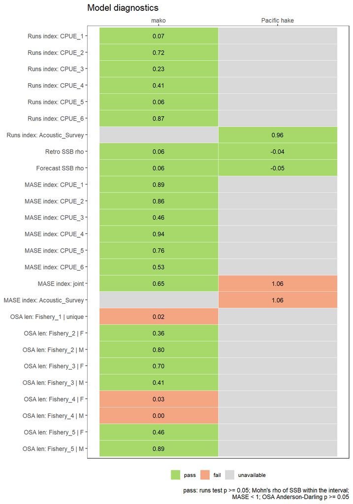

```r
ss3plot_scorecard(sc)
```

> **Using the scorecard.** The scorecard summarises; it does not decide. A model that fails one check is not necessarily worse than one that passes all, and the thresholds are conventions. For ensembles, the scorecard helps to justify which models enter and how they are weighted, but the weights should not be tuned to the advice.

# 10 Conditional age-length key example: European hake in the Adriatic Sea

European hake (*Merluccius merluccius*) in the Adriatic Sea (GFCM geographical subareas 17-18) was benchmarked in 2024 with a two-sex, multi-fleet Stock Synthesis model (FAO GFCM 2024). It is a good example for sex-structured data: length compositions by sex for most fleets, conditional age-at-length data for the Italian trawl (ITA_OTB_18) and longline (ITA_LLS_18) fleets in GSA 18, Richards growth by sex and a male natural mortality twice that of females. This section goes through the diagnostics specific to such data and explains how to read them.

```r
hke <- readRDS(system.file("extdata", "hke.37.17-18", "hke.37.17-18.rds", package = "ss3diags2"))
ss3_fleets(hke)[, .(name, type, ncatch, nindex, nlen)]
```

```
#>           name   type ncatch nindex  nlen
#>         <char> <char>  <int>  <int> <int>
#>  1: ITA_OTB_17  catch     56      0    19
#>  2: HRV_OTB_17  catch     56      0    12
#>  3: HRV_LLS_17  catch     56      0    11
#>  4: HRV_GNS_17  catch     56      0    12
#>  5: ITA_OTB_18  catch     56      0    19
#>  6: ITA_LLS_18  catch     56      0    18
#>  7: MNE_OTB_18  catch     30      0    16
#>  8: ALB_OTB_18  catch     42      0     7
#>  9: MEDITS_ITA survey      0     30    30
#> 10: MEDITS_HRV survey      0     23    23
#> 11: SOLEMON_17 survey      0     20    20
```

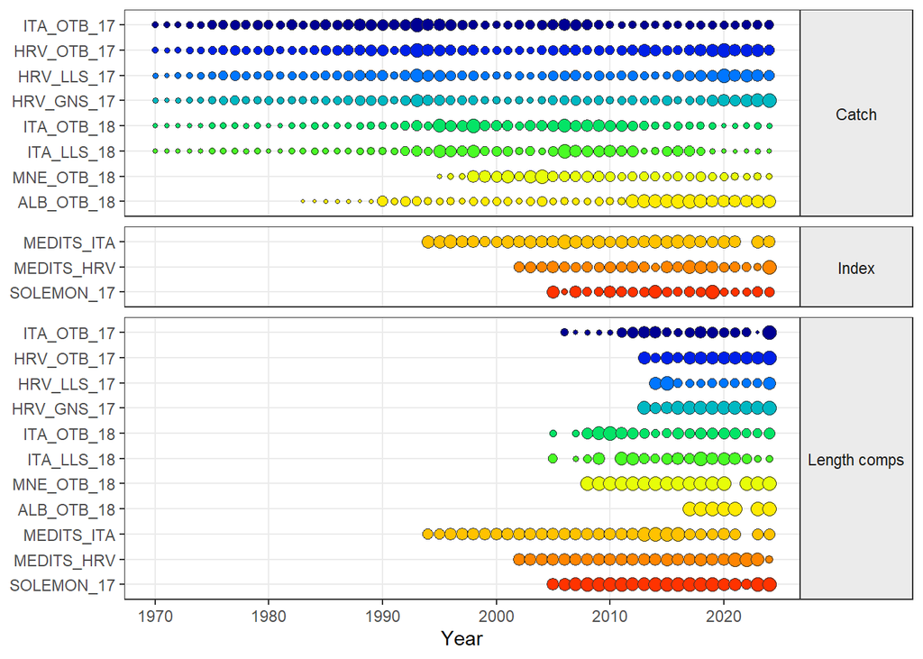

```r
lfh <- ss3_lencomp(hke)
lxh <- ss3_lencomp(hke, what = "exp")
ss3plot_data(catch = ss3_catch(hke), indices = ss3_indices(hke), lencomp = lfh)
```

## 10.1 Growth by sex

`ss3_lhpar()` returns the growth parameters by sex (unit). The model uses Richards growth (Schnute parameterisation); the curves of the plots use it, while `linf`, `k` and `t0` are a von Bertalanffy approximation for FLicc:

```r
lhh <- ss3_lhpar(hke)
lhh[c("L1", "L2", "A1", "A2", "K", "richards", "CVmin", "CVmax", "M"), ]
```

```
#> An object of class "FLPar"
#>           unit
#> params     F      M
#>   L1        8.250  8.513
#>   L2       80.081 61.888
#>   A1        0.500  0.500
#>   A2       12.000 12.000
#>   K         0.436  0.155
#>   richards -0.559  0.531
#>   CVmin     0.200  0.200
#>   CVmax     0.100  0.100
#>   M         0.250  0.500
#> units:  NA
```

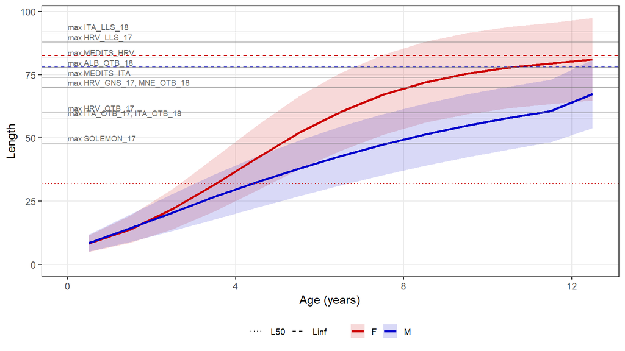

```r
ss3plot_growth(hke, lfd = lfh)
```

> **Reading the growth plot.** Lines are the SS3 mean length at age by sex with $\pm$ 2 SD bands from the CV of length at age; horizontal lines are the largest observed length of each fleet. Females grow to about 80 cm at age 12, males to about 62 cm, and the sexes separate from about age 3. The bands set how far a fish of a given age can be from the mean: they are the key to the conditional age-at-length fits below. The Linf lines belong to the von Bertalanffy approximation (the Richards curve has no Linf of its own) and are only a guide.

## 10.2 Length compositions and sex ratios

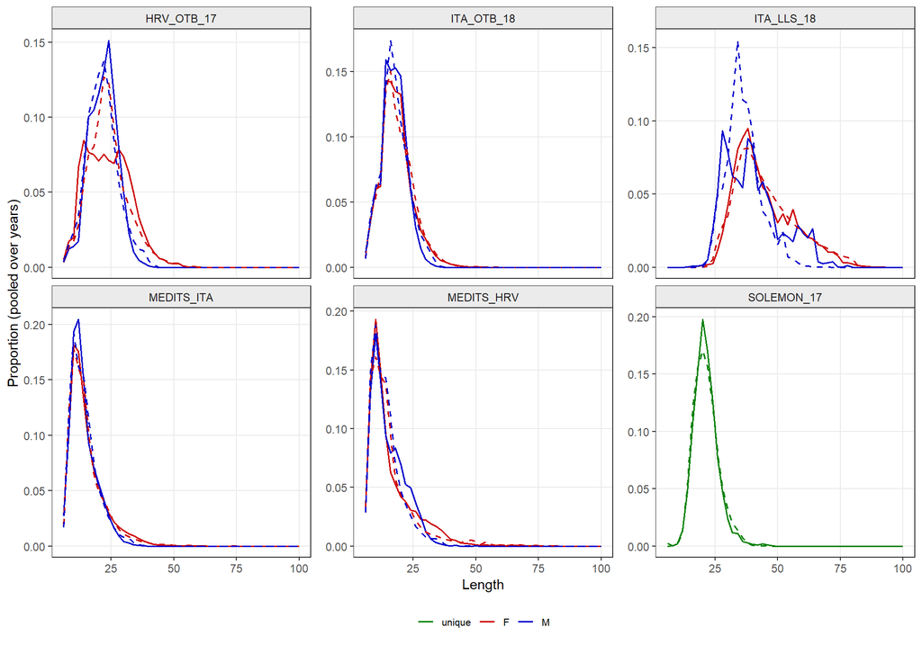

```r
ss3plot_comps(lfh, fit = lxh, by = "unit", fleets = c("ITA_OTB_18", "ITA_LLS_18", "HRV_OTB_17", "MEDITS_ITA",
                                                      "MEDITS_HRV", "SOLEMON_17"))
```

With two sexes, the length compositions also carry the sex ratio. `ss3plot_sexratio()` shows the observed and expected proportion of females by length (pooled over years) or by year (pooled over lengths). The bars are 95% binomial (Wilson) intervals with the numbers in each bin, i.e. the adjusted sample sizes, so they show how far an observed proportion can stray from the line by sampling alone. Bins with fewer than `min.n = 5` effective fish (mostly the largest lengths) get no bar, since their interval would span most of 0-1; `ci = FALSE` removes the bars:

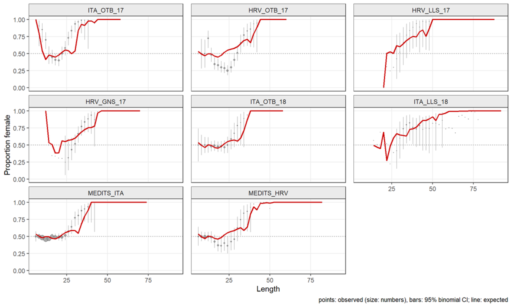

```r
ss3plot_sexratio(lfh, fit = lxh)
```

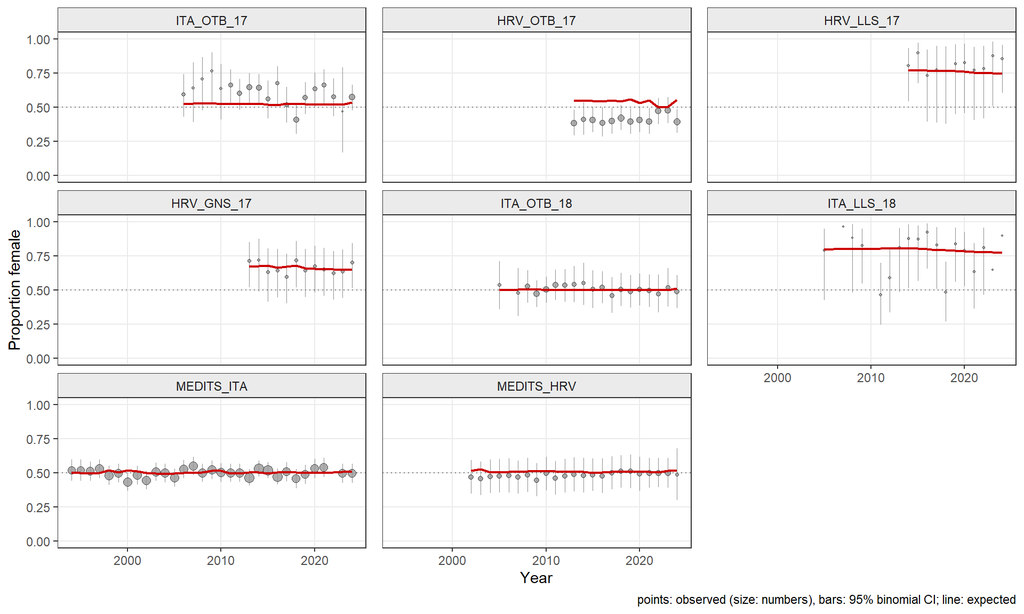

```r
ss3plot_sexratio(lfh, fit = lxh, type = "year")
```

> **Reading sex ratios.** Hake males grow more slowly and die faster (M 0.5 against 0.25), so the share of females rises with length to 100% above about 45 cm. The model follows this switch in all fleets, but in the Croatian trawl and surveys (HRV_OTB_17, MEDITS_HRV, and MEDITS_ITA above 25 cm) the observed switch is steeper: fewer females than expected at about 15-28 cm and more at about 30-40 cm. Males are more common among small fish and drop out of the intermediate lengths faster than modelled: male growth or male mortality differ from the model, selectivity differs between the sexes, or small hake are hard to sex. Where the bars of several neighbouring bins miss the line on the same side (HRV_OTB_17 at 15-28 cm), the pattern is more than sampling noise. A sex ratio that drifts over years, away from the expected line, points to a time-varying process or a change in sampling.

## 10.3 Conditional age-at-length

The conditional age-at-length compositions are strongly down-weighted (SS3 variance adjustments 0.01 and 0.11), so with the adjusted sample size most length bins hold less than one fish and give no residual. With `nsamp = "input"` the residuals use the number of aged fish per length bin:

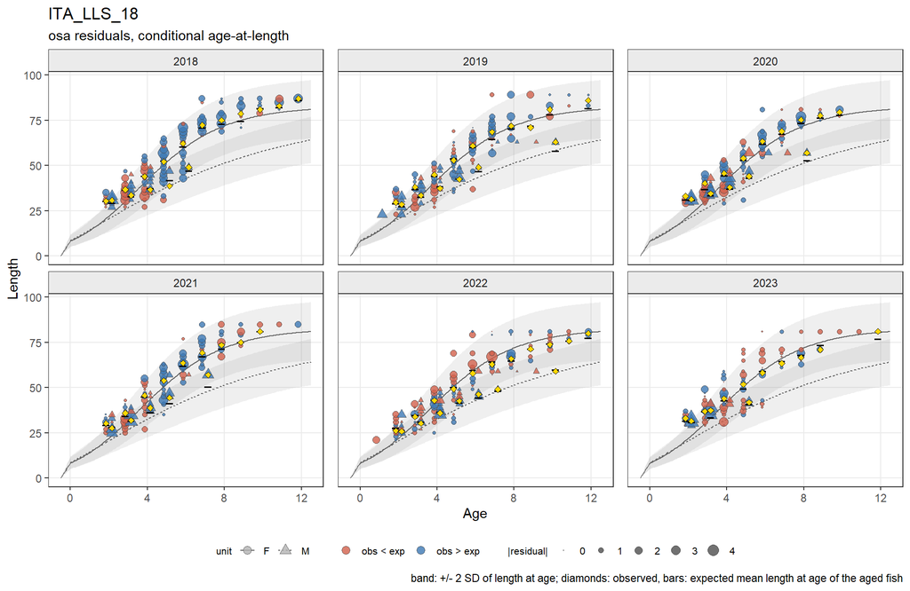

```r
cl <- ss3_resid(hke, quant = "con", long = TRUE, nsamp = "input")
ss3plot_caal(cl, fleet = "ITA_LLS_18", years = 2018:2023, lhpar = lhh)
```

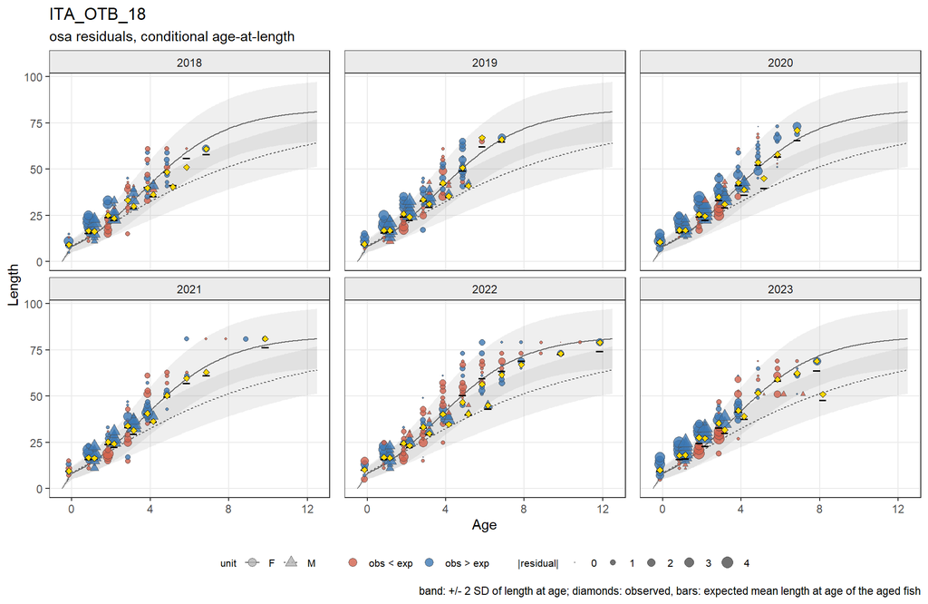

```r
ss3plot_caal(cl, fleet = "ITA_OTB_18", years = 2018:2023, lhpar = lhh)
```

> **Reading the conditional age-at-length plot.** Each panel is a year; x is age (females as circles to the left, males as triangles to the right of each age), y is length. Each row of bubbles (one length bin) is one sample: the ages of the fish of that length. The OSA residual compares the observed with the expected share of each age within the bin, conditioned from the youngest age up (blue: more fish of that age than expected; red: fewer). The curves are the SS3 growth by sex at the sampling time (solid females, dashed males) with $\pm$ 2 SD of length at age (grey).
> - **Diamonds and bars** are the observed and expected mean length at age of the aged fish. Both depend on how the fish were selected by length (here longline fish are large for their age), so they are compared with each other, not with the curve. A diamond away from its bar means the mean growth is off for that age and sex.
> - **Bubbles at the edges of the band** with one colour (blue above and red below the curve) mean length at age varies more than the model’s CV allows.
> - **A diagonal of one colour** moving one age per year is a year class with different growth.

> For Adriatic hake the observed means sit on the expected ones for both sexes and fleets, so the mean growth is consistent with the data: the males above the dashed curve on the longline are large-for-age fish caught by the gear, and the model expects them there. The residual pattern is in the spread: blue at the upper edges of ages 4-8 (longline) and ages 0-3 (trawl), red below. Length at age varies more than the fixed CVs (0.20 young, 0.10 old) allow, in particular for young fish: a sensitivity run estimating the CVs is the natural next step. The residuals use the input sample sizes, which the model down-weights, so their size (SD 1.5-2.4) shows overdispersion; the patterns, not the bubble sizes, matter.

The Francis weights of the conditional age-at-length data compare the mean age by length bin with its expected value, combined over the bins of each year:

```r
fwc <- ss3_francis(hke, "con")
fwc
```

```
#>         fleet         w        lo       hi     n var_adj var_adj.new
#>        <char>     <num>     <num>    <num> <int>   <num>       <num>
#> 1: ITA_OTB_18 0.9672702 0.5481794 3.138015    20    0.01 0.009672702
#> 2: ITA_LLS_18 0.6937138 0.5159726 1.307565    19    0.11 0.076308515
```

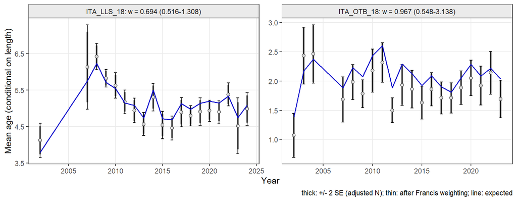

```r
ss3plot_francis(fwc)
```

> **Reading the Francis weights.** The weight multiplies the current variance adjustment (`var_adj.new`). For ITA_OTB_18 it is 0.97, so the current adjustment of 0.01 is about right; for ITA_LLS_18 0.69, suggesting 0.076 instead of 0.11. The wide intervals (39 years in total) show that these weights are only roughly determined.